# ANOVA paso a paso: de Fisher a R

Curso: Introducción a programación y análisis de datos en R

Autor/a

Afiliación

Filip Andras

CIMCYC — Universidad de Granada

Fecha de publicación

15 octubre 2026

# Contexto histórico: Ronald A. Fisher

**Sir Ronald Aylmer Fisher** (1890-1962) desarrolló el ANOVA (ANalysis Of VAriance) en la decada de 1920 mientras trabajaba en la **Rothamsted Experimental Station** en Inglaterra, el centro de investigación agrícola más antiguo del mundo.

Fisher necesitaba comparar el rendimiento de **múltiples variedades de cultivos** simultáneamente. El t-test de Student sólo servía para dos grupos. ¿Cómo comparar 3, 4, o 10 tratamientos a la vez?

Su solución fue elegante: en lugar de comparar medias directamente, **descomponer la varianza total** en componentes explicados e inexplicados.

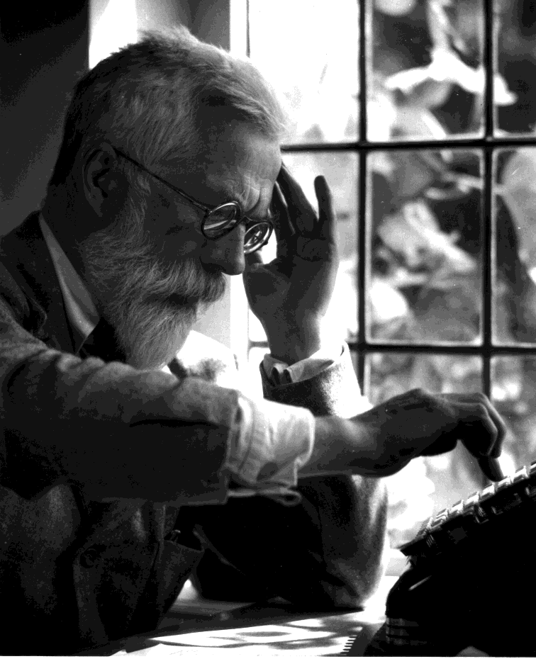

# La lógica del ANOVA

## La pregunta central

> ¿Las diferencias entre las medias de los grupos son **mayores** de lo que esperaríamos por **azar**?

Para responder, comparamos dos fuentes de variabilidad:

1. **Varianza entre grupos** (signal): ¿cuánto difieren las medias de los grupos entre sí?
2. **Varianza dentro de grupos** (noise): ¿cuánto varían las observaciones dentro de cada grupo?

$$F = \frac{\text{varianza entre grupos (signal)}}{\text{varianza dentro de grupos (noise)}}$$

- Si $F \approx 1$: la variabilidad entre grupos no es mayor que el ruido → no hay efecto
- Si $F >> 1$: las medias de los grupos difieren más de lo esperado por azar → hay efecto

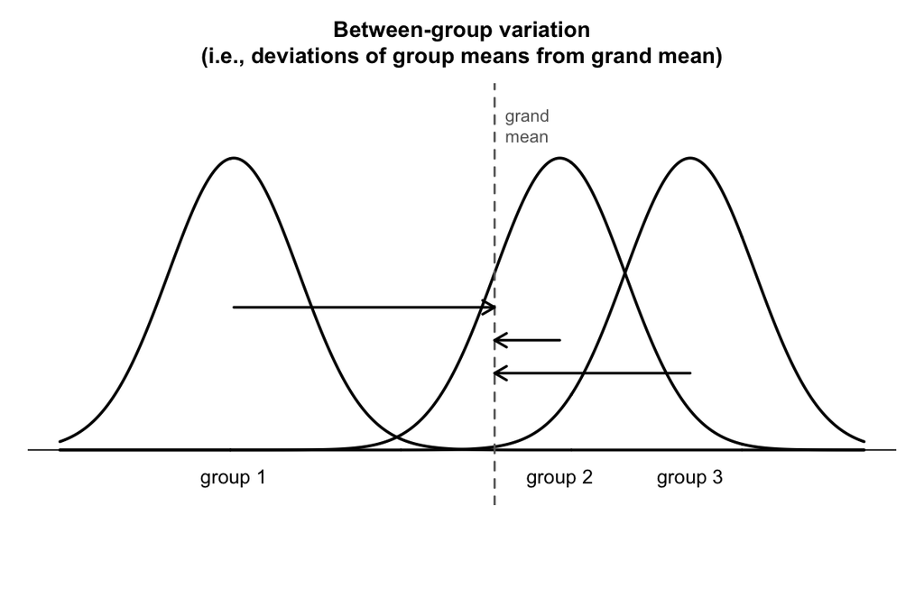

**Varianza entre grupos**: diferencias entre las medias de cada grupo

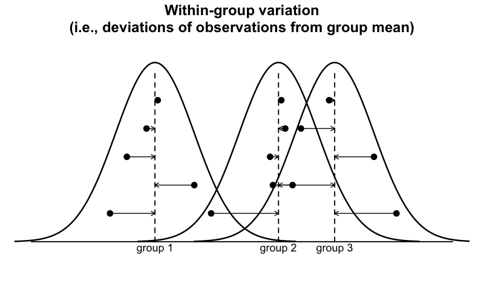

**Varianza dentro de grupos**: dispersión dentro de cada grupo

## ¿Qué pinta tiene una F alta vs una F baja?

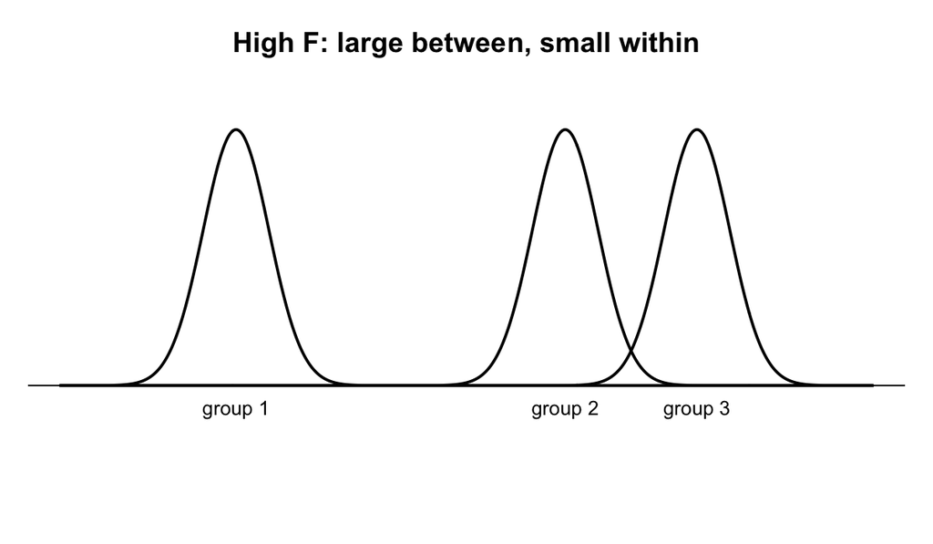

**F alto** — medias separadas, poca variabilidad interna: la señal supera al ruido

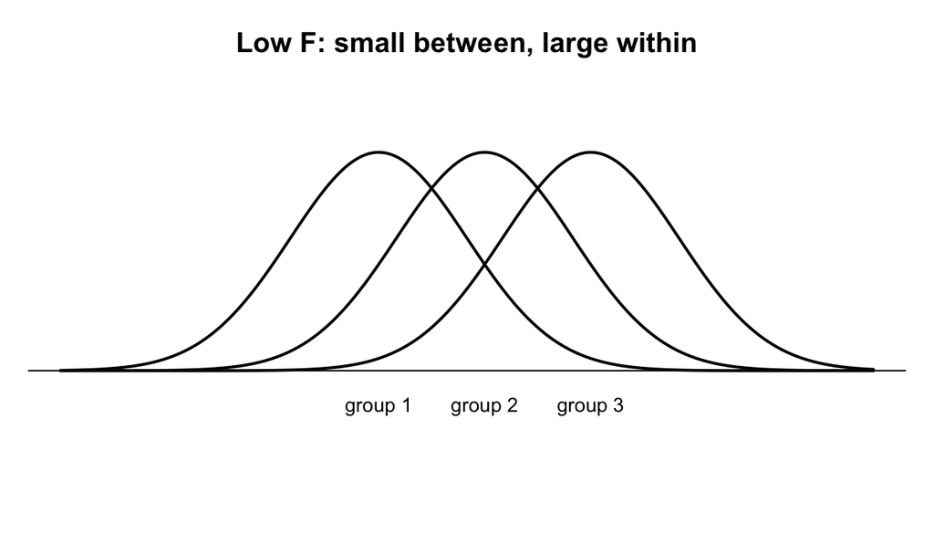

**F bajo** — medias cercanas, mucha variabilidad interna: el ruido enmascara la señal

# La distribución F

([Formulación matemática en Wikipedia](https://en.wikipedia.org/wiki/F-distribution))

## ¿De qué depende?

A diferencia de la distribución t (que depende de un solo df), la distribución F depende de **dos parámetros** de grados de libertad:

- $df_1 = K - 1$ — grados de libertad **entre grupos** (número de grupos menos 1)
- $df_2 = N - K$ — grados de libertad **dentro de grupos** (total de observaciones menos número de grupos)

Por ejemplo, con $K = 3$ grupos y $n = 5$ observaciones por grupo: $df_1 = 3 - 1 = 2$, $df_2 = 15 - 3 = 12$, y usamos la distribución $F(2, 12)$.

La forma de la distribución cambia según ambos parámetros:

**Distribución F para diferentes diseños**

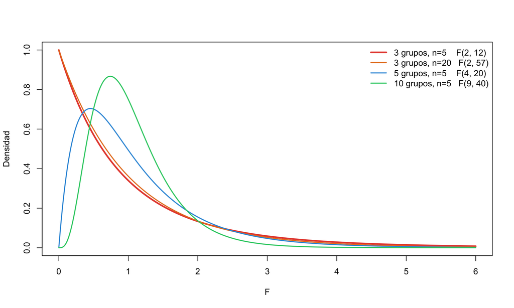

## ¿Cuándo rechazamos H<sub>0</sub>?

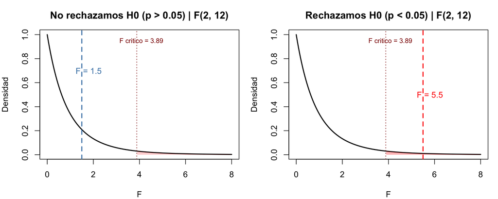

**TipRelación con el t-test**

Cuando sólo hay **2 grupos**, el ANOVA y el t-test dan el **mismo resultado**: $F = t^2$. El ANOVA es una generalización del t-test para más de 2 grupos.

# ANOVA paso a paso: ejemplo del lúpulo

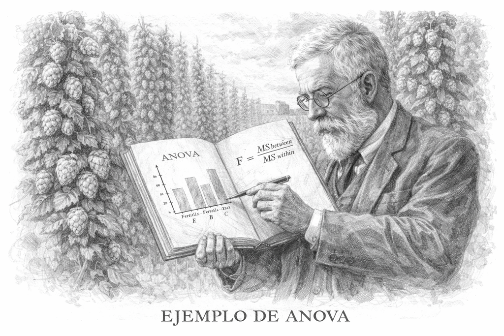

## Los datos

Fisher trabajaba con datos agrícolas. Usaremos un ejemplo en su espíritu: **3 fertilizantes** diferentes aplicados a plantas de **lúpulo** (usado para fabricar cerveza). ¿Producen los fertilizantes diferentes alturas de planta?

```r
# datos: altura de lupulo (cm) con 3 fertilizantes
fert_A <- c(18, 20, 19, 21, 22)   # fertilizante A
fert_B <- c(23, 25, 26, 24, 27)   # fertilizante B
fert_C <- c(21, 22, 23, 20, 24)   # fertilizante C

# combinar en un data frame
datos <- data.frame(
  altura       = c(fert_A, fert_B, fert_C),
  fertilizante = factor(rep(c("A", "B", "C"), each = 5))
)

# parámetros
N   <- nrow(datos)     # N = total de observaciones
K   <- 3               # K = numero de grupos
n_k <- 5               # n_k = observaciones por grupo (igual en todos los grupos)
```

## Paso 0: hipótesis

- **H<sub>0</sub>**: $\mu_A = \mu_B = \mu_C$ (todos los fertilizantes producen la misma altura media)
- **H<sub>1</sub>**: al menos un fertilizante produce una altura media diferente

**NotaNotación: $\mu$ vs $\bar{x}$**

$\mu$ (se pronuncia “mu”, del griego) es la **media poblacional** — el valor verdadero que no conocemos. $\bar{x}$ (“x barra”) es la **media muestral** — la que calculamos a partir de los datos. El objetivo del test es inferir algo sobre $\mu$ a partir de $\bar{x}$.

## Descriptivos

```r
# media global: la media de TODAS las observaciones
media_global <- mean(datos$altura)
print(paste("Media global:", round(media_global, 2)))
```

```
[1] "Media global: 22.33"
```

```r
# medias y SDs por grupo usando tidyverse
library(tidyverse)
datos |>
  group_by(fertilizante) |>
  summarise(
    n     = n(),
    media = round(mean(altura), 2),
    sd    = round(sd(altura), 2)
  )
```

```
# A tibble: 3 x 4
  fertilizante     n media    sd
  <fct>        <int> <dbl> <dbl>
1 A                5    20  1.58
2 B                5    25  1.58
3 C                5    22  1.58
```

## Paso 0b: visualizar los datos

**Código**

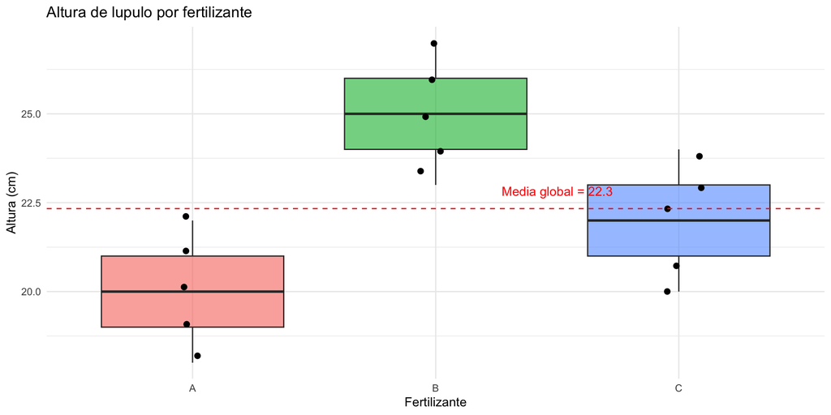

```r
# ggplot2: boxplot con puntos individuales y media global
ggplot(datos, aes(x = fertilizante, y = altura, fill = fertilizante)) +
  geom_boxplot(alpha = 0.6) +
  geom_jitter(width = 0.1, size = 2) +
  geom_hline(yintercept = media_global, linetype = "dashed", color = "red") +
  annotate("text", x = 2.5, y = media_global + 0.5,
           label = paste0("Media global = ", round(media_global, 1)),
           color = "red") +
  labs(x = "Fertilizante", y = "Altura (cm)",
       title = "Altura de lupulo por fertilizante") +
  theme_minimal() +
  theme(legend.position = "none")
```

## Suma de cuadrados: (1) entre grupos, (2) intra grupos

**Paso 1: SSbetween (signal)**

¿Cuánto difieren las **medias de los grupos** de la **media global**? Esta es la varianza **explicada** por los fertilizantes.

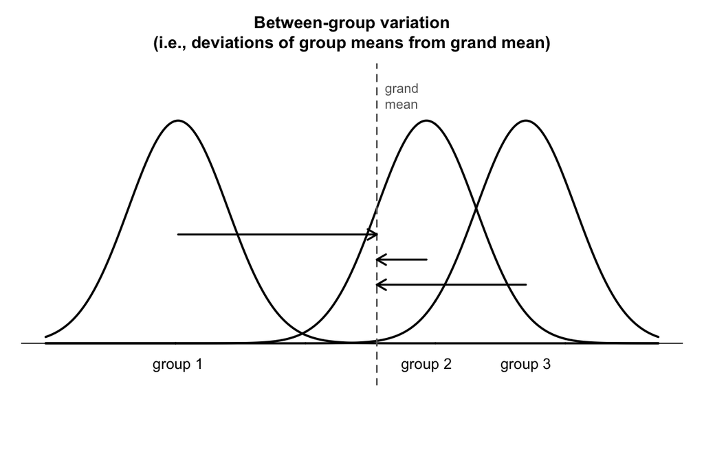

$$SS_{between} = \sum_{k=1}^{K} n_k \times (\bar{Y}_k - \bar{Y})^2$$

Donde:

- $K$ — número de grupos (aquí: 3 fertilizantes)
- $n_k$ — número de observaciones en el grupo $k$
- $\bar{Y}_k$ — media del grupo $k$
- $\bar{Y}$ — media global
- Multiplicamos por $n_k$ porque cada grupo contribuye proporcionalmente a su tamaño

```r
# medias de cada grupo — Y_k — que usaremos para calcular las desviaciones
medias_grupo <- datos |>
  group_by(fertilizante) |>
  summarise(Y_k = mean(altura), .groups = "drop")

print(paste("Media A:", medias_grupo$Y_k[medias_grupo$fertilizante == "A"]))
```

```
[1] "Media A: 20"
```

```r
print(paste("Media B:", medias_grupo$Y_k[medias_grupo$fertilizante == "B"]))
```

```
[1] "Media B: 25"
```

```r
print(paste("Media C:", medias_grupo$Y_k[medias_grupo$fertilizante == "C"]))
```

```
[1] "Media C: 22"
```

```r
# contribucion de cada grupo a SS_between
contrib <- medias_grupo |>
  mutate(
    Y_k          = round(Y_k, 2),                 # media del grupo k (Y barra_k)
    Y_global     = round(media_global, 2),         # media global (Y barra)
    n_k          = n_k,
    diferencia   = round(Y_k - Y_global, 2),       # Y_k - Y_barra
    contribucion = round(n_k * diferencia^2, 2)    # n_k * (Y_k - Y_barra)^2
  )
contrib
```

```
# A tibble: 3 x 6
  fertilizante   Y_k Y_global   n_k diferencia contribucion
  <fct>        <dbl>    <dbl> <dbl>      <dbl>        <dbl>
1 A               20     22.3     5      -2.33        27.1
2 B               25     22.3     5       2.67        35.6
3 C               22     22.3     5      -0.33         0.54
```

```r
SS_between <- sum(contrib$contribucion)
# df_between = K - 1: tenemos K grupos, pero perdemos 1 grado de libertad
# porque la media global (Y_barra) esta fijada por los datos
df_between <- K - 1

print(paste("SS_between =", round(SS_between, 2)))
```

```
[1] "SS_between = 63.32"
```

```r
print(paste("df_between = K - 1 =", K, "- 1 =", df_between))
```

```
[1] "df_between = K - 1 = 3 - 1 = 2"
```

**Paso 2: SSwithin (noise)**

¿Cuánto varían las observaciones **dentro de cada grupo**? Esta es la varianza **no explicada** (ruido).

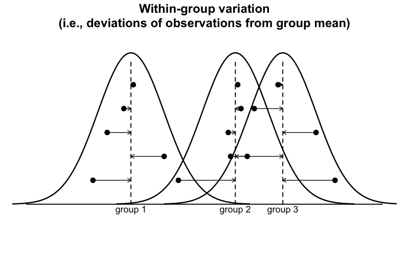

$$SS_{within} = \sum_{k=1}^{K} \sum_{i=1}^{n_k}(Y_{ik} - \bar{Y}_k)^2$$

Donde:

- $Y_{ik}$ — la observación $i$ del grupo $k$
- $\bar{Y}_k$ — la media del grupo $k$
- Sumamos las diferencias al cuadrado **dentro** de cada grupo, y luego sumamos los grupos

```r
# para cada observacion, calcular su desviacion de la media del grupo
ss_por_grupo <- datos |>
  group_by(fertilizante) |>
  mutate(
    Y_k        = round(mean(altura), 2),          # media del grupo k
    diferencia = round(altura - Y_k, 2),           # Y_ik - Y_k
    cuadrado   = round(diferencia^2, 2)            # (Y_ik - Y_k)^2
  ) |>
  ungroup()
ss_por_grupo
```

```
# A tibble: 15 x 5
   altura fertilizante   Y_k diferencia cuadrado
    <dbl> <fct>        <dbl>      <dbl>    <dbl>
 1     18 A               20         -2        4
 2     20 A               20          0        0
 3     19 A               20         -1        1
 4     21 A               20          1        1
 5     22 A               20          2        4
 6     23 B               25         -2        4
 7     25 B               25          0        0
 8     26 B               25          1        1
 9     24 B               25         -1        1
10     27 B               25          2        4
11     21 C               22         -1        1
12     22 C               22          0        0
13     23 C               22          1        1
14     20 C               22         -2        4
15     24 C               22          2        4
```

```r
# sumar los cuadrados dentro de cada grupo por separado
ss_resumen <- ss_por_grupo |>
  group_by(fertilizante) |>
  summarise(
    SS_grupo = sum(cuadrado),
    .groups = "drop"
  )
ss_resumen
```

```
# A tibble: 3 x 2
  fertilizante SS_grupo
  <fct>           <dbl>
1 A                  10
2 B                  10
3 C                  10
```

```r
# SS_within = suma de los SS de cada grupo
SS_within <- sum(ss_resumen$SS_grupo)
# df_within = N - K: perdemos un grado de libertad por cada grupo
# porque estimamos una media (Y_k) dentro de cada grupo
df_within <- N - K

print(paste("SS_within =", round(SS_within, 2)))
```

```
[1] "SS_within = 30"
```

```r
print(paste("df_within = N - K =", N, "-", K, "=", df_within))
```

```
[1] "df_within = N - K = 15 - 3 = 12"
```

```r
# SS_total se deriva de los dos componentes (no necesitamos calcularlo por separado)
SS_total <- SS_between + SS_within
df_total <- N - 1
print(paste("SS_total = SS_between + SS_within =", round(SS_total, 2)))
```

```
[1] "SS_total = SS_between + SS_within = 93.32"
```

## Visualizar la descomposición de varianza

**Código**

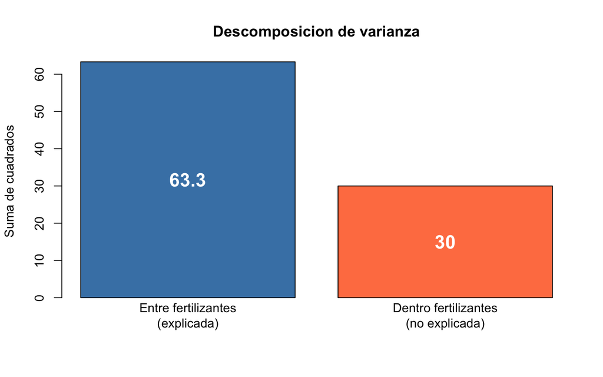

```r
# barplot() crea un grafico de barras
# text() añade texto encima de las barras
barplot(c(SS_between, SS_within),
        names.arg = c("Entre fertilizantes\n(explicada)",
                       "Dentro fertilizantes\n(no explicada)"),
        main = "Descomposicion de varianza",
        ylab = "Suma de cuadrados",
        col = c("steelblue", "coral"))
text(0.7, SS_between / 2, round(SS_between, 1), cex = 1.5, col = "white", font = 2)
text(1.9, SS_within / 2, round(SS_within, 1), cex = 1.5, col = "white", font = 2)
```

## Paso 5: cuadrados medios (Mean Squares)

$$MS_{between} = \frac{SS_{between}}{df_{between}} \qquad MS_{within} = \frac{SS_{within}}{df_{within}}$$

```r
MS_between <- SS_between / df_between
MS_within  <- SS_within  / df_within

print(paste("MS_between =", round(MS_between, 2)))
```

```
[1] "MS_between = 31.66"
```

```r
print(paste("MS_within =", round(MS_within, 2)))
```

```
[1] "MS_within = 2.5"
```

## Paso 6: estadístico F

$$F = \frac{MS_{between}}{MS_{within}}$$

```r
F_obs <- MS_between / MS_within
print(paste("F =", round(F_obs, 2)))
```

```
[1] "F = 12.66"
```

```r
print(paste("Interpretacion: la varianza entre fertilizantes es",
            round(F_obs, 1), "veces mayor que la varianza dentro de cada fertilizante."))
```

```
[1] "Interpretacion: la varianza entre fertilizantes es 12.7 veces mayor que la varianza dentro de cada fertilizante."
```

## Paso 7: p-valor

```r
# pf() calcula la probabilidad acumulada de la distribucion F
# 1 - pf() nos da la probabilidad en la cola derecha (= p-valor)
p_valor <- 1 - pf(F_obs, df1 = df_between, df2 = df_within)
print(paste("p-valor =", round(p_valor, 5)))
```

```
[1] "p-valor = 0.0011"
```

## Visualizar el estadístico F

**Código**

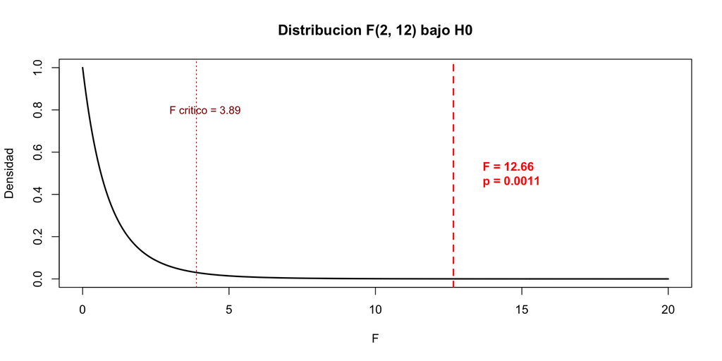

```r
# crear secuencia de valores F para dibujar la curva
# length.out = 500 genera 500 puntos equidistantes
x_seq <- seq(0, max(20, F_obs + 5), length.out = 500)
# df() calcula la densidad de la distribucion F
y_seq <- df(x_seq, df1 = df_between, df2 = df_within)

# plot() dibuja la curva de la distribucion F bajo H0
plot(x_seq, y_seq, type = "l", lwd = 2,
     xlab = "F", ylab = "Densidad",
     main = paste0("Distribucion F(", df_between, ", ", df_within,
                    ") bajo H0"))

# polygon() rellena un area coloreada (aqui: la zona del p-valor)
# rgb(1, 0, 0, 0.3) = rojo con 30% de transparencia
idx <- x_seq >= F_obs
polygon(c(x_seq[idx], rev(x_seq[idx])),
        c(y_seq[idx], rep(0, sum(idx))),
        col = rgb(1, 0, 0, 0.3), border = NA)

# qf() calcula el valor critico de F para alpha = 0.05
f_crit <- qf(0.95, df1 = df_between, df2 = df_within)

# linea vertical del valor critico (p = 0.05)
# lty = 3 es linea punteada
abline(v = f_crit, col = "darkred", lwd = 1, lty = 3)
text(f_crit + 0.3, max(y_seq) * 0.8,
     paste0("F critico = ", round(f_crit, 2)),
     col = "darkred", cex = 0.9)

# abline(v = ...) dibuja una linea vertical en el F observado
# lty = 2 es linea discontinua
abline(v = F_obs, col = "red", lwd = 2, lty = 2)
# text() añade texto en las coordenadas indicadas
# font = 2 es negrita
text(F_obs + 1, max(y_seq) * 0.5,
     paste0("F = ", round(F_obs, 2), "\np = ", round(p_valor, 4)),
     col = "red", adj = 0, font = 2)
```

## Paso 8: calculamos con R

```r
# verificar con aov()
modelo <- aov(altura ~ fertilizante, data = datos)
summary(modelo)
```

```
             Df Sum Sq Mean Sq F value Pr(>F)
fertilizante  2  63.33   31.67   12.67 0.0011 **
Residuals    12  30.00    2.50
---
Signif. codes:  0 '***' 0.001 '**' 0.01 '*' 0.05 '.' 0.1 ' ' 1
```

# Tamaño del efecto: $\eta^2$ y Cohen’s f

**\(\eta^2\) (eta cuadrado)**

Proporción de varianza total explicada por los grupos:

$$\eta^2 = \frac{SS_{between}}{SS_{total}}$$

Donde:

- $SS_{between}$ — varianza explicada por los grupos
- $SS_{total}$ — varianza total
- $\eta^2$ va de 0 (los grupos no explican nada) a 1 (explican toda la varianza)

```r
eta_sq <- SS_between / SS_total
print(paste("eta^2 =", round(eta_sq, 3)))
```

```
[1] "eta^2 = 0.679"
```

Interpretacion: **67.9%** de la varianza en altura se explica por el fertilizante.

**Cohen’s f**

$$f = \sqrt{\frac{\eta^2}{1 - \eta^2}}$$

Donde $\eta^2$ es el eta cuadrado que acabamos de calcular. Cohen’s f transforma la proporción de varianza en una escala más intuitiva para comparar tamaños de efecto.

```r
cohens_f_manual <- sqrt(eta_sq / (1 - eta_sq))
print(paste("Cohen's f =", round(cohens_f_manual, 3)))
```

```
[1] "Cohen's f = 1.453"
```

| f | Interpretación |
| --- | --- |
| 0.10 | Efecto pequeno |
| 0.25 | Efecto mediano |
| 0.40 | Efecto grande |

**Verificar con effectsize**

```r
eta_squared(model = modelo)
```

```
# Effect Size for ANOVA

Parameter    | Eta2 |       95% CI
----------------------------------
fertilizante | 0.68 | [0.33, 1.00]

- One-sided CIs: upper bound fixed at [1.00].
```

```r
cohens_f(model = modelo)
```

```
# Effect Size for ANOVA

Parameter    | Cohen's f |      95% CI
--------------------------------------
fertilizante |      1.45 | [0.71, Inf]

- One-sided CIs: upper bound fixed at [Inf].
```

**Variantes de \(\eta^2\)**

**NotaVariantes de $\eta^2$ que puedes encontrar en los outputs**

- **$\eta^2$** (eta cuadrado) — lo que calculamos aquí: $SS_{between} / SS_{total}$. Proporción de varianza total explicada. Sencillo, pero puede sobreestimar el efecto en diseños con múltiples factores.
- **$\eta^2_p$** (eta cuadrado **parcial**, *partial eta squared*) — $SS_{efecto} / (SS_{efecto} + SS_{error})$. En diseños con múltiples factores (p. ej., fertilizante × riego), el denominador **no incluye** la varianza explicada por los otros factores — solo el efecto que nos interesa y el error. Es lo que reportan por defecto `afex`, SPSS y muchos paquetes de R. En un ANOVA de un solo factor, $\eta^2_p = \eta^2$.
- **$\eta^2_G$** (eta cuadrado **generalizado**, *generalized eta squared*, GES) — una versión que es comparable entre diseños diferentes (entre-sujetos, intra-sujetos, mixtos). Recomendado por Bakeman (2005) y Olejnik & Algina (2003) para reportar en artículos.

En un ANOVA de **un solo factor** (como el nuestro), las tres medidas coinciden. Las diferencias aparecen en diseños factoriales o de medidas repetidas.

# Comparaciones post-hoc

El ANOVA nos dice que **al menos un grupo difiere**, pero no **cuál**. Para eso usamos comparaciones post-hoc:

**Tukey HSD**

```r
TukeyHSD(x = modelo)
```

```
  Tukey multiple comparisons of means
    95% family-wise confidence level

Fit: aov(formula = altura ~ fertilizante, data = datos)

$fertilizante
    diff        lwr        upr     p adj
B-A    5  2.3321363  7.6678637 0.0008342
C-A    2 -0.6678637  4.6678637 0.1545800
C-B   -3 -5.6678637 -0.3321363 0.0277219
```

**emmeans**

```r
library(emmeans)

# medias marginales estimadas (estimated marginal means)
emm <- emmeans(object = modelo, specs = ~ fertilizante)
emm
```

```
 fertilizante emmean    SE df lower.CL upper.CL
 A                20 0.707 12     18.5     21.5
 B                25 0.707 12     23.5     26.5
 C                22 0.707 12     20.5     23.5

Confidence level used: 0.95
```

```r
# comparaciones por pares
# pairs() aplica automáticamente la corrección de Tukey para comparaciones múltiples
# esto controla el error tipo I: sin corrección, al hacer 3 comparaciones
# (A-B, A-C, B-C) la probabilidad de al menos un falso positivo sube
pairs(x = emm)
```

```
 contrast estimate SE df t.ratio p.value
 A - B          -5  1 12  -5.000  0.0008
 A - C          -2  1 12  -2.000  0.1546
 B - C           3  1 12   3.000  0.0277

P value adjustment: tukey method for comparing a family of 3 estimates
```

```r
# si queremos ver sin corrección (no recomendado):
# pairs(emm, adjust = "none")
# otras opciones: adjust = "bonferroni", adjust = "holm"
```

**Tip**

`pairs()` aplica la **corrección de Tukey** por defecto, que ajusta los p-valores para el número de comparaciones realizadas. Esto es importante porque al hacer múltiples comparaciones aumenta el riesgo de falsos positivos (error tipo I).

**Nota**

El fertilizante B produce plantas significativamente más altas que A y C. No hay diferencia significativa entre A y C.

# Supuestos del ANOVA

Como cualquier test estadístico, el ANOVA se basa en algunos supuestos sobre los datos. Hay **tres supuestos clave**:

**ImportanteLos tres supuestos**

1. **Normalidad** — los *residuos* ($\epsilon_{ik}$) se distribuyen normalmente. No es necesario que los datos brutos sean normales, sino los residuos del modelo.
2. **Homogeneidad de varianzas** (homocedasticidad) — la varianza poblacional ($\sigma^2$) es la misma para todos los grupos. Es decir, no permitimos que cada grupo tenga su propia varianza $\sigma_k^2$; asumimos una $\sigma^2$ común.
3. **Independencia** — los residuos son independientes entre sí. Conocer un residuo no nos dice nada sobre otro. Este supuesto se garantiza con el **diseño experimental** (aleatorización), no con un test estadístico.

**Normalidad**

Comprobamos la normalidad de los **residuos** del modelo, no de los datos brutos. Dos herramientas:

### QQ plot (visual)

Un QQ plot compara los cuantiles de nuestros residuos con los cuantiles teóricos de una distribución normal. Si los puntos caen sobre la diagonal, los residuos son aproximadamente normales.

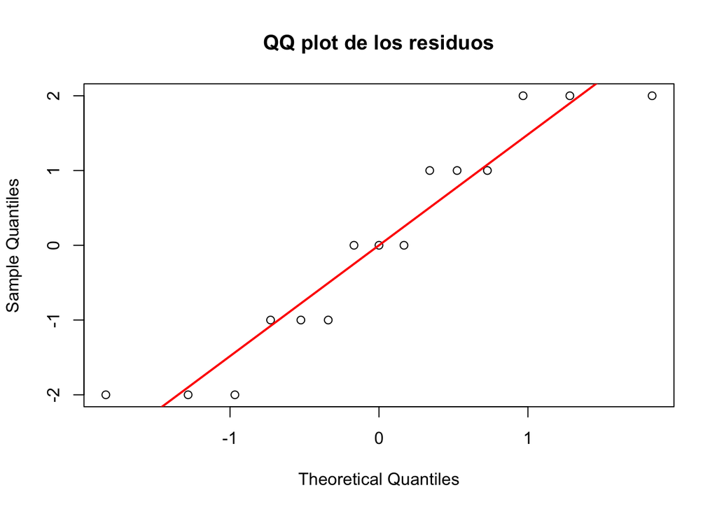

```r
# extraer los residuos del modelo
residuos <- residuals(modelo)

# QQ plot
qqnorm(residuos, main = "QQ plot de los residuos")
qqline(residuos, col = "red", lwd = 2)
```

**Tip**

**Cómo leer un QQ plot:**

- Puntos sobre la línea = normalidad OK
- Curvatura en los extremos = colas pesadas (leptocúrtica) o ligeras (platicúrtica)
- Curvatura sistemática = asimetría (skewness)

### Shapiro-Wilk (formal)

```r
# test de Shapiro-Wilk sobre los residuos
shapiro.test(x = residuos)
```

```
    Shapiro-Wilk normality test

data:  residuos
W = 0.90219, p-value = 0.1028
```

**Nota**

Si $p > 0.05$, **no rechazamos** la hipótesis nula de normalidad. Esto no “demuestra” que los datos sean normales — sólo que no tenemos evidencia suficiente para rechazar la normalidad.

**Ojo:** con muestras grandes el Shapiro-Wilk detecta desviaciones triviales. Por eso siempre conviene mirar el QQ plot además del test.

**Homogeneidad de varianzas**

El supuesto de homocedasticidad dice que $\sigma_1^2 = \sigma_2^2 = \sigma_3^2$. Lo comprobamos con el **test de Levene**:

```r
# test de Levene (del paquete car)
car::leveneTest(y = altura ~ fertilizante, data = datos)
```

```
Levene's Test for Homogeneity of Variance (center = median)
      Df F value Pr(>F)
group  2       0      1
      12
```

**Nota**

Si $p > 0.05$, **no rechazamos** la igualdad de varianzas — el supuesto se cumple razonablemente.

Si se viola este supuesto, una alternativa es el **Welch ANOVA** (`oneway.test()`), que no asume varianzas iguales:

```r
oneway.test(altura ~ fertilizante, data = datos, var.equal = FALSE)
```

**Independencia**

El supuesto de independencia **no se comprueba con un test estadístico**. Se garantiza con el **diseño del estudio**:

- **Aleatorización** en la asignación a grupos
- Cada observación proviene de un **participante distinto**
- No hay relación entre los residuos (e.g., no son medidas repetidas del mismo sujeto)

**Advertencia**

Si las observaciones **no son independientes** (e.g., medidas repetidas, datos agrupados por escuela/hospital), necesitamos un modelo diferente: **ANOVA de medidas repetidas** o **modelos mixtos**.

# ¿Cómo reportar los resultados?

```r
# resumen del modelo
summary(modelo)
```

```
             Df Sum Sq Mean Sq F value Pr(>F)
fertilizante  2  63.33   31.67   12.67 0.0011 **
Residuals    12  30.00    2.50
---
Signif. codes:  0 '***' 0.001 '**' 0.01 '*' 0.05 '.' 0.1 ' ' 1
```

```r
# report::report() genera un parrafo de resultados listo para copiar en un articulo
library(report)
report(x = modelo)
```

```
The ANOVA (formula: altura ~ fertilizante) suggests that:

  - The main effect of fertilizante is statistically significant and large (F(2, 12) = 12.67, p = 0.001; Eta2 = 0.68, 95%
CI [0.33, 1.00])

Effect sizes were labelled following Field's (2013) recommendations.
```

**Tip**

`report::report()` genera automáticamente un párrafo de resultados en formato APA — con F, df, p y tamaño del efecto. Ideal para copiar directamente en el artículo.

# Más allá del ANOVA de un factor

Este documento cubrio el ANOVA de **un factor** (one-way). En el curso también veremos:

| Diseño | Descripción | Ejemplo |
| --- | --- | --- |
| **Medidas repetidas** | Mismo sujeto medido varias veces | Pre/post tratamiento |
| **Factorial** | Dos o más factores cruzados | Grupo x sexo |
| **Mixto** | Factores entre- y intra-sujetos | Grupo (entre) x tiempo (intra) |

Estos se cubren en las presentaciones del **Dia 4**.

# Conexión con la regresión lineal

El ANOVA es un **caso particular** de la regresión lineal, donde los predictores son categóricos:

```r
# el mismo análisis con lm()
modelo_lm <- lm(altura ~ fertilizante, data = datos)
summary(modelo_lm)
```

```
Call:
lm(formula = altura ~ fertilizante, data = datos)

Residuals:
   Min     1Q Median     3Q    Max
    -2     -1      0      1      2

Coefficients:
              Estimate Std. Error t value         Pr(>|t|)
(Intercept)    20.0000     0.7071   28.28 0.00000000000237 ***
fertilizanteB   5.0000     1.0000    5.00         0.000309 ***
fertilizanteC   2.0000     1.0000    2.00         0.068655 .
---
Signif. codes:  0 '***' 0.001 '**' 0.01 '*' 0.05 '.' 0.1 ' ' 1

Residual standard error: 1.581 on 12 degrees of freedom
Multiple R-squared:  0.6786,    Adjusted R-squared:  0.625
F-statistic: 12.67 on 2 and 12 DF,  p-value: 0.001103
```

```r
# el estadístico F y p-valor son idénticos
print(paste("F de aov():", round(summary(modelo)[[1]]$`F value`[1], 4)))
```

```
[1] "F de aov(): 12.6667"
```

```r
print(paste("F de lm(): ", round(summary(modelo_lm)$fstatistic[1], 4)))
```

```
[1] "F de lm():  12.6667"
```

**Nota**

`aov()` y `lm()` dan exactamente el **mismo resultado**. ANOVA no es un test diferente a la regresión — es la misma herramienta matemática con predictores categóricos.